# ICY0006 Probability And Statistics - Exercise 1

This is Exercise 1 from ICY0006 course - Probability And Statistics

Exercise is as follows:  
You have randomized 2 groups of patients, A and B, who take two drugs (A  
and B, respectively). From each patient you measure blood sugar (smaller  
values are better). Please analyse these data and plot the results. Explain  
your analytic choices. What do you conclude from you analysis?  
A) Is drug A reliably different from drug B? explain you answer.  
B) In the absence of other evidence, (i) is it more likely that A is better  
than B, or (ii) is it more likely that B is better, or (iii) does evidence point  
to A and B being equal, or (iv) is it true that we cannot say either way,  
based on available evidence.  
C) If you needed to take either drug A or B, which one would you choose  
(or would you just toss a coin to make the choice).  
D) Suppose that your sample size would have been 50, instead of 5. Would  
you have plotted the data differently? if yes, how? Would you have analysed  
the data differently in any way? if yes, explain how and why.  
E) Suppose that your sample size would have been 500, instead of 5. Would  
you have plotted the data differently? if yes, how? Would you have analysed  
the data differently in any way? if yes, explain how and why.

| Group | Value |
| --- | --- |
| A | 0.2273642 |
| A | 0.1700281 |
| A | 0.3781713 |
| A | 0.6344903 |
| A | 0.9484044 |
| B | 1.7099361 |
| B | 5.7520838 |
| B | 0.3314107 |
| B | 0.9291784 |
| B | 2.8027043 |

And we initialize the values for further use:

```r
A <- c(0.2273642,0.1700281,0.3781713,0.6344903,0.9484044)
B <- c(1.7099361, 5.7520838, 0.3314107, 0.9291784, 2.8027043)
```

# A) Is drug A reliably different from drug B? explain your answer.

As a disclaimer, it has to be stated that five entries per data set is painfully small amount of data, and in real life no real conclusion can be based on such data. Keeping that in mind we will try to answer this question.

To arrive at a conclusion for this question, let’s compare the statistical data and its properties of the two drugs.

First, let’s graph the data from two groups

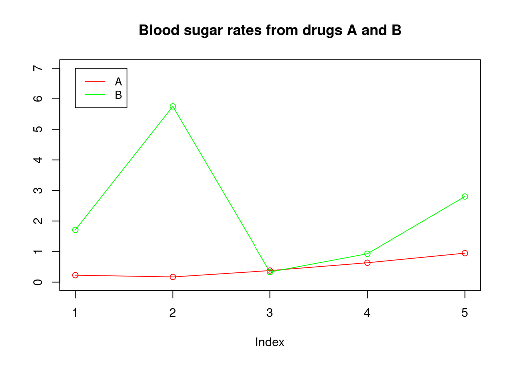

```r
plot(A, type = "o", col = "red", ylab = "", ylim = c(0, 7),
     main = "Blood sugar rates from drugs A and B")
lines(B, type = "o", col = "green")
legend(1, 7, legend = c("A", "B"),
 col = c("red", "green"), lty = 1:1, cex = 0.9)
```

It is evident that just by these measures, the two data sets are widely different.

Running them through a t-test is also informative:

```r
t.test(x=A, var.equal=T, paired=F, conf.level = 0.999)
```

```
##
##  One Sample t-test
##
## data:  A
## t = 3.2817, df = 4, p-value = 0.03045
## alternative hypothesis: true mean is not equal to 0
## 99.9 percent confidence interval:
##  -0.7659195  1.7093028
## sample estimates:
## mean of x
## 0.4716917
```

```r
t.test(x=B, var.equal=T, paired=F, conf.level = 0.999)
```

```
##
##  One Sample t-test
##
## data:  B
## t = 2.4116, df = 4, p-value = 0.07343
## alternative hypothesis: true mean is not equal to 0
## 99.9 percent confidence interval:
##  -5.924903 10.535029
## sample estimates:
## mean of x
##  2.305063
```

Plugging these values into the earlier graph we get:

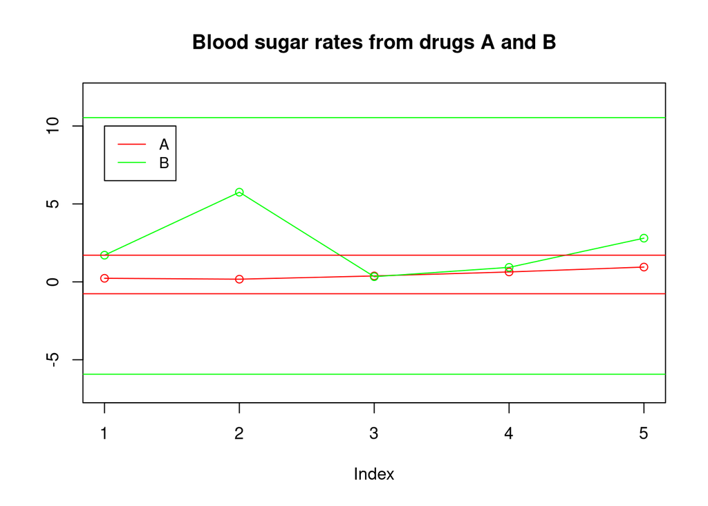

```r
plot(A, type = "o", col = "red", ylab = "", ylim = c(-7, 12),
     main = "Blood sugar rates from drugs A and B")
lines(B, type = "o", col = "green")
abline(h=-0.7659195, col="red")
abline(h=1.7093028, col="red")
abline(h=-5.924903, col="green")
abline(h=10.535029, col="green")
legend(1, 10, legend = c("A", "B"),
 col = c("red", "green"), lty = 1:1, cex = 0.9)
```

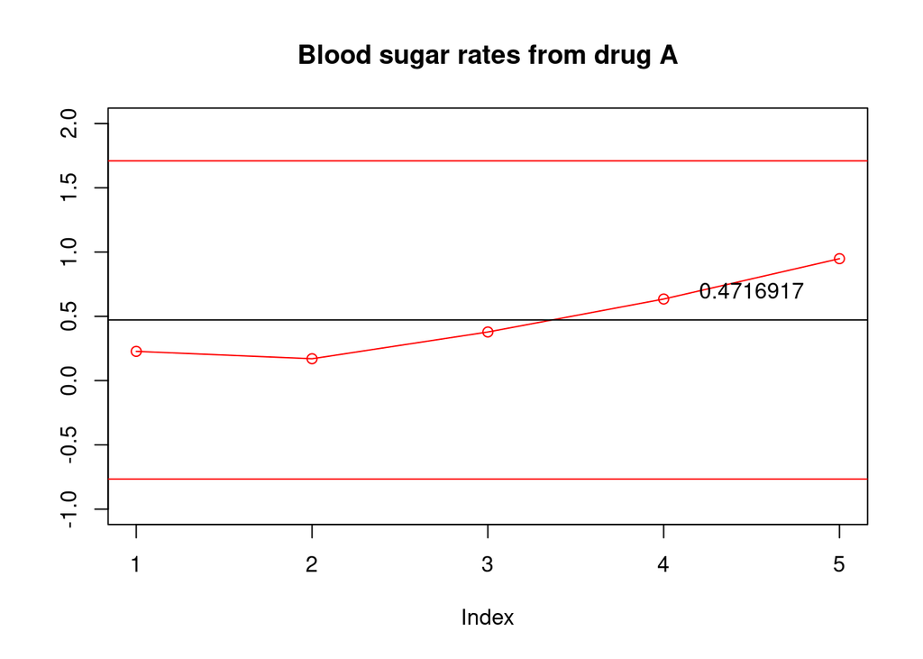

```r
plot(A, type = "o", col = "red", ylab = "", ylim = c(-1, 2),
     main = "Blood sugar rates from drug A")
abline(h=-0.7659195, col="red")
abline(h=1.7093028, col="red")
abline(h=0.4716917)
text(4.5, 0.7, "0.4716917")
```

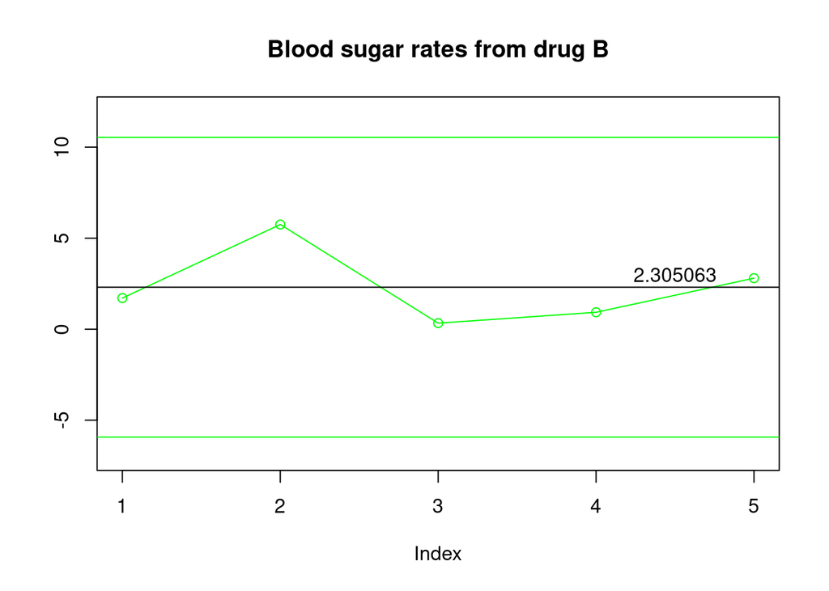

```r
plot(B, type = "o", col = "green", ylab = "", ylim = c(-7, 12),
     main = "Blood sugar rates from drug B")
abline(h=-5.924903, col="green")
abline(h=10.535029, col="green")
abline(h=2.305063)
text(4.5, 3, "2.305063")
```